# Explore province of Bolzano raster data

The [Geoportal](http://geocatalogo.retecivica.bz.it/geokatalog/#!home&layer=p_bz%3Aca9738bc-5913-454b-bf3a-97197e577fd8) of the province of Bolzano also provides raster data such as orthophotos (from various years) and Digital Terrain Models (DTM).

By means of these data we are therefore able to visualise what the real morphology of the area actually looks like. Furthermore, thanks to the DTMs we can investigate a third dimension: the altitude of this area.

#### Set up and data loading

```python
import geopandas as gpd
import rasterio as rio
from owslib.wms import WebMapService
from rasterio import MemoryFile
from rasterio.plot import show
from rasterio.mask import mask
import contextily as ctx
from functions import *

province_BZ = load_province('Bolzano', 'data\Limiti01012021_g\ProvCM01012021_g')
geodf_dolomities = load_geodf_dolomities('data\I nove Sistemi delle Dolomiti UNESCO.kml')
dolomities_BZ_clipped = lead_province_clipped_dolomiti('Bolzano', 'data\Limiti01012021_g')
geo_dolomiti_BZ_mun = load_province_dolomiti_mun(21, 'data\Limiti01012021_g')
area_dolomiti_BZ = dissolve_province_dolomiti_area(21)
```

### Explore province's geoservices

#### Web Map Services

In addition to offering Web Features Services, the Geoportal also has a Web Map Service that makes available data such as ortophotos and DTMs of various types.

```python
import warnings
warnings.filterwarnings('ignore')
wms_BZ = "http://geoservices.buergernetz.bz.it/qgis?SERVICE=WCS"
wms = WebMapService(wms_BZ)
```

Show all the resources:

```python
list(wms.contents)
```

```
['P_BZ_OF_2020',
 'P_BZ_OF_2017_CIR',
 'P_BZ_OF_2014_AGEA',
 'P_BZ_OF_2014_2015_2017',
 'P_BZ_OF_2014_2015',
 'P_BZ_OF_2014',
 'P_BZ_OF_2011_CIR',
 'P_BZ_OF_2011_20cm',
 'P_BZ_OF_2011',
 'P_BZ_OF_2008',
 'P_BZ_OF_2006',
 'P_BZ_OF_2003',
 'P_BZ_OF_2000',
 'Orthophoto_1992_97',
 'Orthophoto_1982_85',
 'P_BZ_OF_1992_1997',
 'P_BZ_OF_1982_1985',
 'BASEMAP_5000_2007',
 'BASEMAP_10000_2007']
```

*P_BZ_OF_2020* represent the 2020's ortophoto, lets' visualize it.

Get bounding box and CRS's options:

```python
wms['P_BZ_OF_2020'].crsOptions
```

```
['EPSG:25832', 'EPSG:3857', 'CRS:84', 'EPSG:4326']
```

```python
wms['P_BZ_OF_2020'].boundingBox
```

```
(1153230.0, 5807080.0, 1394440.0, 5964480.0, 'EPSG:3857')
```

Get the image:

```python
bbox = wms['P_BZ_OF_2020'].boundingBox[0:4]
epsg = wms['P_BZ_OF_2020'].boundingBox[4]
request = wms.getmap(
    layers=['P_BZ_OF_2020'],
    srs=epsg,
    format='image/jpeg',
    bbox=bbox,
    size=(833,606)
    )
```

Visualize the ortophoto:

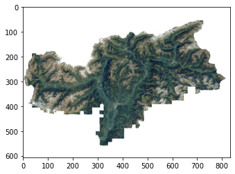

```python
import warnings
warnings.filterwarnings('ignore')

image = MemoryFile(request).open()
show(image)
```

It appears to be cutted in the area of interest (Dolomiti), so let's try with older data:

```python
wms['P_BZ_OF_2014_AGEA'].boundingBox
bbox = wms['P_BZ_OF_2014_AGEA'].boundingBox[0:4]
epsg = wms['P_BZ_OF_2020'].boundingBox[4]
```

```python
request = wms.getmap(
    layers=['P_BZ_OF_2014_AGEA'],
    srs=epsg,
    format='image/jpeg',
    bbox=bbox,
    size=(833,606)
    )
```

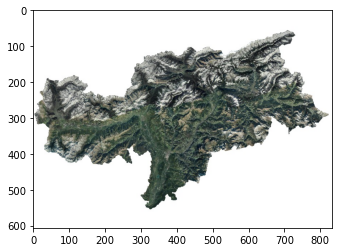

```python
raster = MemoryFile(request).open()
show(raster)
```

These ortophoto seems to be more complete. We can therefore get an idea of the landforms in the Dolomites of the province.

Check raster dimension and colors:

```python
raster.width
```

```
833
```

```python
raster.height
```

```
606
```

Visualize RGB colours:

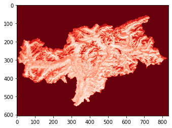

```python
show((raster, 1), cmap='Reds')
```

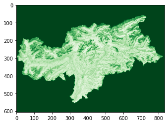

```python
show((raster, 3), cmap='Greens')
```

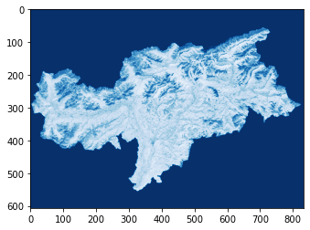

```python
show((raster, 3), cmap='Blues')
```

### Get the DTM and crop it on the province dolomiti area

We will use the DTM of the whole province of Bolzano's alpine region to make sure that our area is included.

Open downloaded DTM with rasterio:

```python
raster_dtm = rio.open('data\Raster_alpine_region\p_bz-Elevation_DigitalTerrainModel-20m-Hillshade.tif')
```

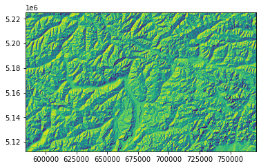

```python
show(raster_dtm)
```

Check metadata (width, height, CRS...):

```python
raster_dtm.meta
```

```
{'driver': 'GTiff',
 'dtype': 'uint8',
 'nodata': None,
 'width': 7137,
 'height': 4305,
 'count': 1,
 'crs': CRS.from_epsg(25832),
 'transform': Affine(26.267575793, 0.0, 583578.5807889907,
        0.0, -26.267575798, 5225341.55676949)}
```

We will clip this raster on `area_dolomiti_BZ` GeoDataFrame:

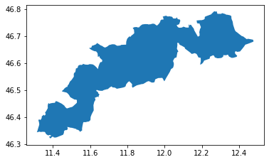

```python
area_dolomiti_BZ.plot()
```

First we have to to get features from GeoDataFrame so that the `rasterio`'s functions is able to process them.

```python
def getFeatures(gdf):
    import json
    return [json.loads(gdf.to_json())['features'][0]['geometry']]
```

Convert the GeoDataFrame CRS and extract features:

```python
area_dolomiti_BZ_25832 =area_dolomiti_BZ.to_crs(epsg=25832)
coords = getFeatures(area_dolomiti_BZ_25832)
```

Crop the raster with `raterio` `mask()` function:

```python
raster_area_dolomiti, raster_area_dolomiti_transform = mask(raster_dtm, coords, crop=True)
```

Visualize Dolomiti area clipped raster:

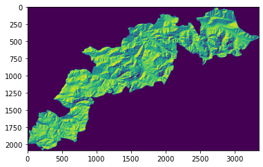

```python
show(raster_area_dolomiti)
```

Save it as a GeoTiff updating metadata:

```python
raster_area_dolomiti_meta = raster.meta
```

```python
raster_area_dolomiti_meta.update({"driver": "GTiff",
                 "height": raster_area_dolomiti.shape[1],
                 "width": raster_area_dolomiti.shape[2],
                 "transform": raster_area_dolomiti_transform,
                 "count": 1})

with rio.open("data/raster_area_dolomiti_orthophoto.tif", "w", **raster_area_dolomiti_meta) as dest:
    dest.write(raster_area_dolomiti)
```

### Indagate the altitude difference of the longest cableway

Since DTM could contain data about the 3rd dimension (altitude), let's indagate it to obtain some interesting information, such as the cableways' altitude difference. In this process we will only consider one cable car, the largest one, however, as the DTM of the whole province is available it is clearly possible to calculate the height difference of each of them. However, extending the process to all ropeways requires handling large files which we want to avoid for this notebook.

Get province's skilift data clipped on Dolomiti area:

```python
ski_lifts_BZ_clipped = load_BZ_dolomiti_ski_lift_data("data\Ski_lifts_data")
```

Find the longest ski lifts/cableway:

```python
longest = ski_lifts_BZ_clipped[ski_lifts_BZ_clipped.LENGTH == ski_lifts_BZ_clipped.LENGTH.max()]
print("The longest ski lift in Bolzano's Dolomiti's area is '", longest.NAME_IT.values[0], "' with lengyt ", round(longest.LENGTH.values[0]/10**3, 3) ," km", sep= "")
```

```
The longest ski lift in Bolzano's Dolomiti's area is 'Alpe di Siusi' with lengyt 4.086 km
```

```python
longest
```

|  | OBJECTID | SKIKEY | PLR | SKIZONE | NAME_IT | NAME_DE | LENGTH | SHAPE | geometry |
| --- | --- | --- | --- | --- | --- | --- | --- | --- | --- |
| 318 | 69132.0 | 10.02 | 10.0 | 2.0 | Alpe di Siusi | Seiseralm | 4086.3 | None | LINESTRING (11.56396 46.54021, 11.57109 46.540... |

Where is this cableway (in which municipality)?

```python
longest_mum = geo_dolomiti_BZ_mun[geo_dolomiti_BZ_mun.contains(longest.geometry.values[0])]
longest_mum
```

|  | COD_REG | COD_PROV | PRO_COM_T | COMUNE | Shape_Area | geometry |
| --- | --- | --- | --- | --- | --- | --- |
| 2773 | 4 | 21 | 021019 | Castelrotto | 1.177940e+08 | POLYGON ((11.56492 46.59659, 11.57231 46.59478... |

We can also merge the ski lift data with municipality data using spatial join for possible further investigations: some ski lifts and cableway are contained by more than one municipality.

```python
ski_lifts_with_mun = gpd.sjoin(ski_lifts_BZ_clipped, geo_dolomiti_BZ_mun, how='left', predicate='intersects', lsuffix='dolomities', rsuffix='provinces')
```

```python
ski_lifts_with_mun[ski_lifts_with_mun.OBJECTID == longest.OBJECTID.values[0]]
```

|  | OBJECTID | SKIKEY | PLR | SKIZONE | NAME_IT | NAME_DE | LENGTH | SHAPE | geometry | index_provinces | COD_REG | COD_PROV | PRO_COM_T | COMUNE | Shape_Area |
| --- | --- | --- | --- | --- | --- | --- | --- | --- | --- | --- | --- | --- | --- | --- | --- |
| 318 | 69132.0 | 10.02 | 10.0 | 2.0 | Alpe di Siusi | Seiseralm | 4086.3 | None | LINESTRING (11.56396 46.54021, 11.57109 46.540... | 2773 | 4 | 21 | 021019 | Castelrotto | 1.177940e+08 |

Plot the longest cableway on the dolomiti area and its municipality

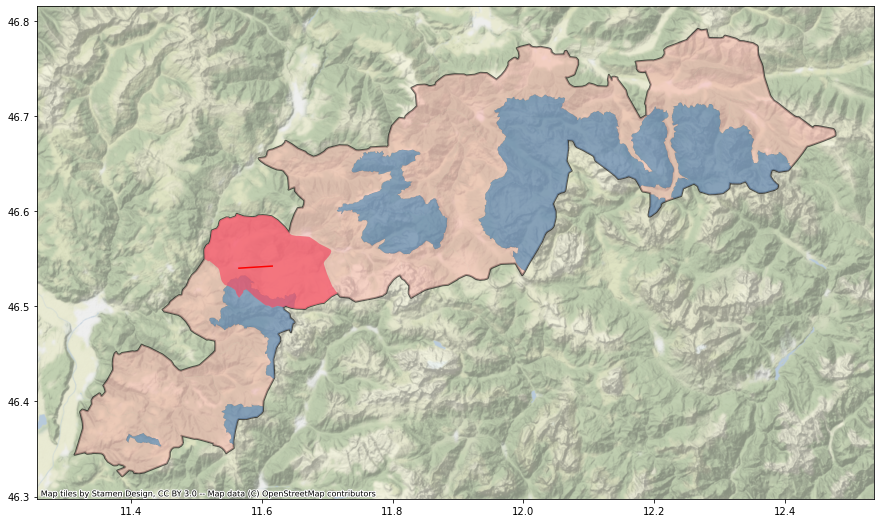

```python
base = area_dolomiti_BZ.plot(
    figsize=(15,15),
    facecolor="none",
    edgecolor="k",
    alpha=0.6,
    lw=2,)

ctx.add_basemap(base, crs=area_dolomiti_BZ.crs.to_string(), source=ctx.providers.Stamen.TerrainBackground, alpha=0.7)

geo_dolomiti_BZ_mun.plot(ax=base,
    cmap="Pastel1",
    column='COD_PROV',
    alpha=0.5)

dolomities_BZ_clipped.to_crs(epsg=4326).plot(
    ax=base,
    edgecolor="k",
    alpha=0.5,
    lw=0.1,
)

longest_mum.plot(ax=base,
    color="#F65167",
    alpha=0.7
)

longest.plot(
    ax=base,
    color="red"
)
```

Get `longest` features with the previous defined function:

```python
longest_4326 = longest.to_crs(epsg=4326)
coords_longest = getFeatures(longest_4326)
```

#### Download DTM data with vertical dimension

The province's Geoportal allow to bounding the area of interest to avoid handling the whole province raster (too large a file). So we can download Cstelrotto's area DTM.

[figure not shown]

Open Castelrotto's DTM:

```python
raster_castelrotto = rio.open('data\Castelrotto_raster\p_bz-Elevation_DigitalTerrainModel-2.5m.tif')
```

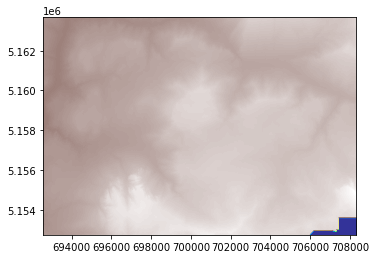

```python
show(raster_castelrotto, cmap='terrain')
```

Check metadata:

```python
raster_castelrotto.meta
```

```
{'driver': 'GTiff',
 'dtype': 'float32',
 'nodata': None,
 'width': 6308,
 'height': 4376,
 'count': 1,
 'crs': CRS.from_epsg(25832),
 'transform': Affine(2.4999999997440585, 0.0, 692558.7500021332,
        0.0, -2.50000000033907, 5163678.749876623)}
```

Extract altitude values vector:

```python
data = raster_castelrotto.read(1)
data
```

```
array([[  849.39,   849.4 ,   849.34, ...,  2144.09,  2145.96,  2147.93],
       [  849.34,   849.19,   848.63, ...,  2144.52,  2146.23,  2148.01],
       [  849.2 ,   848.08,   847.47, ...,  2145.48,  2147.23,  2148.62],
       ...,
       [  902.13,   901.15,   900.84, ..., -9999.  , -9999.  , -9999.  ],
       [  901.4 ,   901.03,   900.94, ..., -9999.  , -9999.  , -9999.  ],
       [  902.15,   901.78,   901.4 , ..., -9999.  , -9999.  , -9999.  ]],
      dtype=float32)
```

Check Maximum height:

```python
data.max()
```

```
2956.85
```

Check Minimum height:

```python
data.min() # due to the shape (the blue hole in the image)
```

```
-9999.0
```

This value is due to the "blue hole" in the DTM image

#### What is the altitude difference of the longest cableway? 🚠

We need to rasform DTM CRS in order to have meter as unit:

```python
import shapely
import pyproj
from shapely.ops import transform

wgs84 = pyproj.CRS('EPSG:4326')
crs_dtm = pyproj.CRS('EPSG:25832')
projection_transform = pyproj.Transformer.from_crs(wgs84, crs_dtm, always_xy=False).transform
```

We use a function to convert Points' longitude and latitude:

```python
def convert(x,y):
    p = shapely.geometry.Point(y,x)
    p = transform(projection_transform,p)
    return(p)
```

Create two arrays for x and y (longitude and latitude):

```python
pointsx = []
pointsy = []
for coordinate in longest.geometry.values[0].coords:
  x = coordinate[0]
  y = coordinate[1]
  point = convert(x,y)
  pointsx.append(point.x)
  pointsy.append(point.y)
```

Calculate the distance point-to-point (we basically obtain the length of the linestring updated at each point):

```python
import pandas as pd

from shapely.geometry import Point,LineString
lengths = []
previousPoint = None
length = 0
for i in range(len(pointsx)):
  point = shapely.geometry.Point(pointsy[i],pointsx[i])
  if previousPoint is None:
    lengths.append(length)
  else:
    length = LineString([previousPoint,point]).length + length
    lengths.append(length)
  previousPoint = point
```

```python
lengths
```

```
[0,
 548.1321324826865,
 671.6382309110555,
 739.7570003143445,
 845.8157132330692,
 1368.45268512941,
 2003.9914533135588,
 2774.6864939567545,
 2827.774460389724,
 4007.983852219015,
 4021.02225702942,
 4086.297505033714]
```

Extract the altitude value for each point:

```python
rows, cols = rio.transform.rowcol(raster_castelrotto.transform,(pointsx),(pointsy))
```

```python
values = []
for i in range(len(rows)):
    values.append(data[rows[i]-1][cols[i]-1])
```

```python
values
```

```
[1009.19,
 1062.27,
 1082.27,
 1076.65,
 1097.02,
 1214.6,
 1575.68,
 1693.55,
 1696.76,
 1854.81,
 1854.47,
 1854.85]
```

Save altitude values for each point in a DataFrame:

```python
siusi_3d = pd.DataFrame()
siusi_3d['value'] = values
siusi_3d['length'] = lengths
siusi_3d
```

|  | value | length |
| --- | --- | --- |
| 0 | 1009.190002 | 0.000000 |
| 1 | 1062.270020 | 548.132132 |
| 2 | 1082.270020 | 671.638231 |
| 3 | 1076.650024 | 739.757000 |
| 4 | 1097.020020 | 845.815713 |
| 5 | 1214.599976 | 1368.452685 |
| 6 | 1575.680054 | 2003.991453 |
| 7 | 1693.550049 | 2774.686494 |
| 8 | 1696.760010 | 2827.774460 |
| 9 | 1854.810059 | 4007.983852 |
| 10 | 1854.469971 | 4021.022257 |
| 11 | 1854.849976 | 4086.297505 |

Plot the data:

```
[]
```

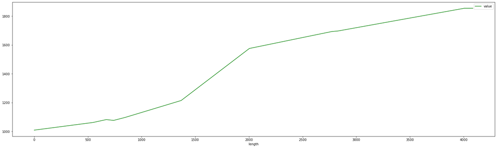

```python
ax = siusi_3d.plot(y="value",x="length",color='green',figsize=(28,8))
ax.plot()
```

As mentioned on the [Dolomities Seise Alm website](https://www.seiseralm.it/it/attivita/vacanze-estive/escursioni/impianti-di-risalita.html), the cableway starts from 1000 metres and goes up to 1800 metres, thus our results seems to be quite accurate:

"L’area escursionistica si raggiunge in tutta comodità e rapidità con moderni impianti di risalita collegati in maniera impeccabile ai sentieri dell’altipiano. I bus-navetta conducono dalle diverse località di Castelrotto, Siusi allo Sciliar, Fiè allo Sciliar e Tires al Catinaccio alla stazione a valle della cabinovia Alpe di Siusi, che consente di passare velocemente **da 1.000 a 1.800 m s.l.m.**"